# Hack_earth_Predict_Categories

## **edgeverve - hackerearth**

### Task : predict ‘Product Category’, given invoice information.

Here, In our target variable we are having 36- classes, We Can Consider it as Multiclass classification Problem.

### Approach :

1. Read the documents into a list to form a corpus.
2. Tokenize the words.
3. Remove stop words (include stop words observed from data also).
4. Pos - tagging , Filtered only NN,NNS(Because, In Our Corpus We Can Observe that Nouns are Important Features).
5. Convert into TF-IDF matrix.
6. Build model using most important features.
7. Split data into Train and Test.
8. Used Random Forest , GBM models
9. Evaluation metrics.

```python
import os
import pandas as pd
import numpy as np
from matplotlib.pyplot import figure
from matplotlib import pyplot as plt
%matplotlib inline
#from time import strptime
import seaborn as sns
import random
import re
import nltk
from nltk.corpus import stopwords
from nltk.stem.porter import PorterStemmer
from sklearn.feature_extraction.text import TfidfVectorizer
from sklearn.model_selection import train_test_split
from sklearn.model_selection import cross_val_score
from sklearn.model_selection import KFold
from nltk.corpus import wordnet
nltk.download('wordnet')
from nltk.tokenize import word_tokenize
from nltk import pos_tag
from wordcloud import WordCloud,STOPWORDS
```

```python
#df=pd.read_excel (r'D:\\dataset\\Approach.xlsx', sheet_name='Sheet1')
#df.head(3)
```

```python
os.chdir("D:\\dataset\\solution_1")
train_data = pd.read_csv("Train.csv")
test_data = pd.read_csv("Test.csv")

#train_data.isnull().sum()
train_data.Product_Category.unique()
print("Train data Shape is :",train_data.shape)
print("Test data Shape is :",test_data.shape)
train_data.head()

print("no of unique vendor_codes {}".format(train_data.Vendor_Code.nunique()),"; no of unique GL_Codes {}".format(train_data.GL_Code.nunique()),"; no of unique Product_Category {}".format(train_data.Product_Category.nunique()))
```

```
Train data Shape is : (5566, 6)
Test data Shape is : (2446, 5)
no of unique vendor_codes 1253 ; no of unique GL_Codes 9 ; no of unique Product_Category 36
```

### Target Distribution :

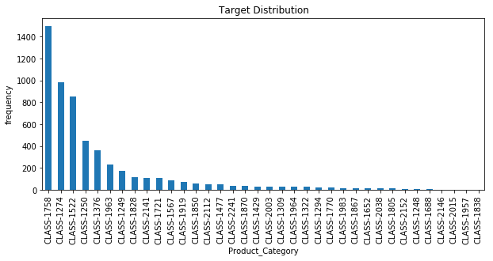

```python
figure(figsize=(10,4))
train_data.Product_Category.value_counts().plot(kind="bar")
plt.xlabel("Product_Category")
plt.ylabel("frequency")
plt.title("Target Distribution")
```

In Above Plot We can observe that Our Target is having Imbalanced classes.

```python
train_data.head()
```

|  | Inv_Id | Vendor_Code | GL_Code | Inv_Amt | Item_Description | Product_Category |
| --- | --- | --- | --- | --- | --- | --- |
| 0 | 15001 | VENDOR-1676 | GL-6100410 | 83.24 | Artworking/Typesetting Production Jun 2009 Cha... | CLASS-1963 |
| 1 | 15002 | VENDOR-1883 | GL-2182000 | 51.18 | Auto Leasing Corporate Services Corning Inc /N... | CLASS-1250 |
| 2 | 15004 | VENDOR-1999 | GL-6050100 | 79.02 | Store Management Lease/Rent Deltona Corp Real ... | CLASS-1274 |
| 3 | 15005 | VENDOR-1771 | GL-6101400 | 48.50 | Store Construction General Requirements Coloni... | CLASS-1522 |
| 4 | 15006 | VENDOR-1331 | GL-2182000 | 63.35 | Jul 2015 Aydin Corp Contingent Labor/Temp Labo... | CLASS-1376 |

### Text Statisctics :

```python
train_stat =train_data['Item_Description'].map(lambda x: len(x.split(' ')))
train_stats =train_stat.describe().reset_index().rename(columns={'index':'train_stat'})

## Test data
test_data = pd.read_csv("Test.csv")
test_stat =test_data['Item_Description'].map(lambda x: len(x.split(' ')))
test_stats =test_stat.describe().reset_index().rename(columns={'index':'test_stat'})
test_stats

len_sts = pd.concat([train_stats, test_stats], axis=1)
display(len_sts)
```

|  | train_stat | Item_Description | test_stat | Item_Description |
| --- | --- | --- | --- | --- |
| 0 | count | 5566.000000 | count | 2446.000000 |
| 1 | mean | 17.727991 | mean | 17.455846 |
| 2 | std | 8.984625 | std | 8.606288 |
| 3 | min | 7.000000 | min | 8.000000 |
| 4 | 25% | 13.000000 | 25% | 13.000000 |
| 5 | 50% | 15.000000 | 50% | 15.000000 |
| 6 | 75% | 19.000000 | 75% | 19.000000 |
| 7 | max | 63.000000 | max | 59.000000 |

```python
def word_cloud_plt(data,colour,tlt):
    word_cloud = WordCloud(width = 1000, height = 500, stopwords = STOPWORDS, background_color = colour).generate(
                        ' '.join(data['Item_Description']))

    plt.figure(figsize = (15,8))
    plt.imshow(word_cloud)
    plt.axis('off')
    plt.title(tlt)
    plt.show()
```

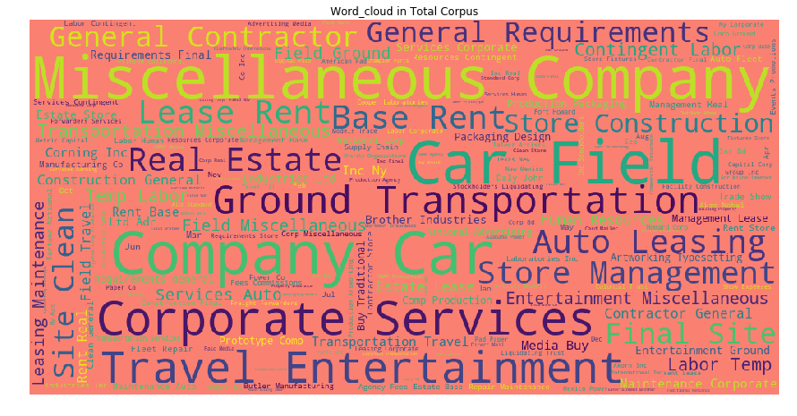

```python
word_cloud_plt(train_data,'salmon','Word_cloud in Total Corpus')
```

"Auto Leasing","Real Estate","Transportation","Corporate Services" ...,are frequently Occuring .

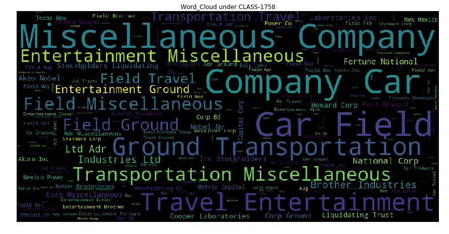

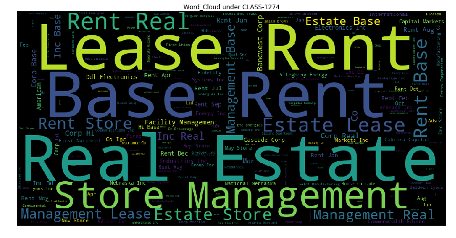

```python
dt1=train_data.loc[train_data['Product_Category']=="CLASS-1758",]
dt2=train_data.loc[train_data['Product_Category']=="CLASS-1274",]

word_cloud_plt(dt1,'black','Word_Cloud under CLASS-1758')
word_cloud_plt(dt2,'black','Word_Cloud under CLASS-1274')
```

### Data Preprocess :

```python
def pre_processing(data):

    lt = []

    for i in range(len(data)):
        lt.append(data['Item_Description'][i])

    ps= PorterStemmer()
    desc=[ps.stem(word) for word in lt if not word in set(stopwords.words('english'))]
    corpus =[]
    desc = ''.join(desc)
    desc=re.sub('[/,&(,),-," ",0-9]',' ',desc)
    corpus.append(desc)
    sentances = nltk.sent_tokenize(desc)
    sentances = [nltk.word_tokenize(sent) for sent in sentances]

    ## Here ,I'm converting list of list to flated list.

    mm=[]
    def flat_list(sentances):

        for i in sentances:
            if type(i)==list:
                flat_list(i)
            else:
                mm.append(i)

    flat_list(sentances)

## Here, I'm removing some more stop words.

    stop_words = ['jan','feb','mar','apr','may','jun','jul','aug','sep','oct','nov','dec','co','and','up','ny',
              'j','of','hi','out',"'s'",'new','or','it','r','co.','llc']

    dic={}

    for word in [word for word in mm if word not in stop_words]:
        if word in dic.keys():
            dic[word] +=1
        else:
            dic[word]=1

#Here, I am doing POS-tagging.

    features = nltk.pos_tag(sorted(dic, key=dic.get,reverse=True)[1:250])

    allowed_word_types = ["NN","NNS"]
    all_words=[]

    for i in features:
        if i[1] in allowed_word_types:
            all_words.append(i[0])

    freq_wrods = list(set(all_words))

    ## Spell Check ##

    mistakes = [token for token in freq_wrods if len(wordnet.synsets(token)) == 0 ]
    spells = [token for token in freq_wrods if len(wordnet.synsets(token)) > 0 ][:100]

    #print(len(spells))

    add_voc =["VBG"]
    add_words=[]

    for i in features:
        if i[1] in add_voc:
            add_words.append(i[0])
    feature_words = (spells+add_words)

    return feature_words
```

```python
train_features = pre_processing(train_data)
```

```python
train_features
```

```
['supply',
 'fixtures',
 'post',
 'life',
 'iii',
 'expenses',
 'fortune',
 'talent',
 'base',
 'advertising',
 'air',
 'collateral',
 'facility',
 'insurance',
 'services',
 'media',
 'fees',
 'contractor',
 'show',
 'relations',
 'fidelity',
 'data',
 'funds',
 'charity',
 'models',
 'labor',
 'search',
 'fleet',
 'brokerage',
 'property',
 'trust',
 'postage',
 'comp',
 'stockholders',
 'card',
 'energy',
 'john',
 'commissions',
 'promotions',
 'resources',
```

[output cut: 52 more lines]

```
 'packaging',
 'field',
 'aquila',
 'pad',
 'car',
 'rent',
 'power',
 'bd',
 'leasing',
 'corning',
 'artworking',
 'typesetting',
 'liquidating',
 'ealing',
 'holding']
```

```python
tfidf_vec = TfidfVectorizer(ngram_range=(1,1),vocabulary=train_features)
tfidf = tfidf_vec.fit_transform(train_data['Item_Description'])
tfidf_final =tfidf.todense()
final_dt = pd.DataFrame(tfidf_final)
final_dt.shape
```

```
(5566, 107)
```

```python
final_dt['Target']=train_data['Product_Category']
final_dt = final_dt.iloc[np.random.permutation(len(final_dt))]
train_n = final_dt[0:int(len(final_dt)*0.7)]
test_n = final_dt[int(len(final_dt)*0.7):]
print("train_data shape :", str(train_n.shape),
      "Test_data shape : ",str(test_n.shape))
```

```
train_data shape : (3896, 108) Test_data shape :  (1670, 108)
```

### Randomforest Model :

```python
from sklearn.ensemble import RandomForestClassifier
from sklearn.metrics import accuracy_score

clf = RandomForestClassifier(n_estimators=100,random_state=0)
clf.fit(train_n.ix[:,:-1],train_n.ix[:,-1])

pred_n = clf.predict(train_n.ix[:,:-1])
train_acc = accuracy_score(train_n.ix[:,-1],pred_n)

print(train_acc)

test_pred_n = clf.predict(test_n.ix[:,:-1])

test_acc_n = accuracy_score(test_n.ix[:,-1],test_pred_n)

print(test_acc_n)
```

```
0.9987166324435318
0.9970059880239521
```

### K-Fold Cross Validation :

```python
x=final_dt.drop(['Target'],axis=1)
y=final_dt['Target']

scores = cross_val_score(clf, x, y, cv=8)
scores
```

```
array([0.99159664, 0.99435028, 0.99573257, 0.99570815, 0.99710145,
       0.99854227, 0.99561404, 0.99706745])
```

### Apply on Test data :

```python
test_features = pre_processing(test_data)
```

```python
#tfidf_vec = TfidfVectorizer(ngram_range=(1,1),vocabulary=train_features)
tfidf_test = tfidf_vec.fit_transform(test_data['Item_Description'])
final_test =tfidf_test.todense()
final_dt_test = pd.DataFrame(final_test)
final_dt_test.shape
```

```
(2446, 107)
```

```python
test_data['Product_Category']= clf.predict(final_dt_test) ### Applied random forest with unigram ##
test_data[['Inv_Id','Product_Category']].to_csv("Final_Submissions.csv",index=False)
```

## GBM :

```python
###
from sklearn.ensemble import GradientBoostingClassifier

gbm = GradientBoostingClassifier()
gbm.fit(train_n.ix[:,:-1],train_n.ix[:,-1])
pred_n = gbm.predict(train_n.ix[:,:-1])
train_acc = accuracy_score(train_n.ix[:,-1],pred_n)

print(train_acc)

test_pred_n = gbm.predict(test_n.ix[:,:-1])

test_acc_n = accuracy_score(test_n.ix[:,-1],test_pred_n)

print(test_acc_n)
```

```
0.9987166324435318
0.9958083832335329
```

```python
x=final_dt.drop(['Target'],axis=1)
y=final_dt['Target']

scores = cross_val_score(gbm, x, y, cv=8)
scores
```

```
array([0.99159664, 0.99293785, 0.99288762, 0.99284692, 0.99565217,
       0.99708455, 0.99707602, 0.99560117])
```

### Test :

```python
test_data['Product_Category']= gbm.predict(final_dt_test) ### Applied random forest with unigram ##
test_data[['Inv_Id','Product_Category']].to_csv("Final_Submissions.csv",index=False)
```

### Save the model to pickle file :

```python
import pickle
with open("Final_Model.pickle",'wb') as f:
    pickle.dump(gbm,f)
```

```python
from sklearn.metrics import accuracy_score,classification_report
print(classification_report(test_n.ix[:,-1], gbm.predict(test_n.ix[:,:-1])))
```

```
              precision    recall  f1-score   support

  CLASS-1248       0.00      0.00      0.00         1
  CLASS-1249       1.00      1.00      1.00        56
  CLASS-1250       1.00      1.00      1.00       127
  CLASS-1274       1.00      1.00      1.00       311
  CLASS-1294       1.00      1.00      1.00         8
  CLASS-1309       1.00      1.00      1.00         8
  CLASS-1322       1.00      1.00      1.00         3
  CLASS-1376       1.00      1.00      1.00       124
  CLASS-1429       1.00      1.00      1.00        10
  CLASS-1477       1.00      1.00      1.00        14
  CLASS-1522       1.00      1.00      1.00       234
  CLASS-1567       1.00      1.00      1.00        22
  CLASS-1652       0.83      1.00      0.91         5
  CLASS-1688       1.00      1.00      1.00         1
  CLASS-1721       1.00      1.00      1.00        43
  CLASS-1758       1.00      1.00      1.00       452
  CLASS-1770       1.00      1.00      1.00         6
  CLASS-1805       0.00      0.00      0.00         3
  CLASS-1828       1.00      1.00      1.00        37
  CLASS-1850       1.00      1.00      1.00        19
  CLASS-1867       1.00      1.00      1.00         6
  CLASS-1870       1.00      1.00      1.00        11
  CLASS-1919       1.00      1.00      1.00        16
  CLASS-1957       0.00      0.00      0.00         1
  CLASS-1963       1.00      1.00      1.00        71
  CLASS-1964       1.00      1.00      1.00         6
  CLASS-1983       1.00      1.00      1.00         2
  CLASS-2003       1.00      1.00      1.00        10
  CLASS-2015       0.00      0.00      0.00         0
  CLASS-2038       1.00      0.83      0.91         6
  CLASS-2112       1.00      0.93      0.97        15
  CLASS-2141       0.97      1.00      0.98        31
  CLASS-2152       0.50      1.00      0.67         3
  CLASS-2241       1.00      1.00      1.00         8

   micro avg       1.00      1.00      1.00      1670
   macro avg       0.86      0.88      0.87      1670
weighted avg       0.99      1.00      0.99      1670
```